# Assignment 1 and 2 - Variable Changes

Whytne Stevens

9/19/2020

# Assignment 1 and 2 - Variable Changes

While working on assignment 3 I realized I needed to change some of my variables due to overly detailed variables that were making my analysis more complex.I still am interested in looking at whether there’s a connection between one’s profession, English language proficiency,household language and their income and income to poverty ratio. I stll narrowed down my analysis to person level data for Dallas County, Texas from Public Use Microdata Sample (PUMAs) provided by the 2018 1 year American Community Survey. I have selected the following variables to explore this question:

- Class of Worker (COW) (categorical)
- English ability (ENG) (categorical)
- Household Language (HHL) (categorical)
- Food Stamps (FS)(Categorical)
- Total Person’s Income (PINCP) (continuous)
- Hours worked per week (WKHP) (continuous)
- Income to Poverty Ratio (POVPIP) (continuous)
- Adjustment factor for income and earnings dollar amounts (6 implied decimal places) (ADJINC)(Continuous)*

*used for PINCP Variable

## Variables I added and took away

In place of the specific occupation variable, I used class of worker since this simplifies the occupations to the type of employee a person is as opposed to their particular occupation, therefore simplifying my analysis added food stamps to better understand who might be receiving public assistance of some sort since public assistance is usually used as an indicator of some type of financial hardship if not poverty. I also added household language as I wanted to see if there are some correlations there as it relates to languages and income/poverty. As for the variables I took away, race, sex, and specific occupation weren’t necessarily adding to my analysis and if anything were complicating it further, particularly the specific occupation and race variables.

# Set Up and Data Output

I also set up everything below as in Assignment 1

```r
library(ggplot2)
library(tidycensus)
library(ggthemes)
library(tidyverse)
```

```r
person_vars_2018 <- pums_variables %>%
  distinct(year, survey, var_code,
           var_label, data_type, level) %>%
  filter(level == "person", year == 2018, survey == "acs1")
```

```r
area_vars_2018 <- load_variables(2018, "acs1")
```

```r
dallas_county <- c("02301", "02302", "02303", "02304", "02308", "02317", "02318", "02319", "02320", "02321", "02322")
```

```r
person_data_new <- get_pums(variables = c("PUMA",
                                      "COW",
                                      "HHL",
                                      "ENG",
                                      "FS",
                                      "PINCP",
                                      "WKHP",
                                      "POVPIP",
                                      "ADJINC"),
                        state = "TX",
                        year = 2018,
                        survey = "acs1",
                        recode = TRUE) %>%
  filter(PUMA == dallas_county,
         PINCP > 0,
         WKHP > 0,
         POVPIP > 0) %>%
  select(COW_label, HHL_label, ENG_label, FS_label, PINCP, WKHP, POVPIP)
```

```r
 head(person_data_new, 1)
```

```
## # A tibble: 1 x 7
##   COW_label                      HHL_label ENG_label FS_label PINCP  WKHP POVPIP
##   <chr>                          <chr>     <chr>     <chr>    <dbl> <dbl>  <dbl>
## 1 Employee of a private for-pro~ Spanish   Well      No       30000    40    118
```

```r
 tail(person_data_new, 596)
```

```
## # A tibble: 557 x 7
##    COW_label            HHL_label    ENG_label      FS_label  PINCP  WKHP POVPIP
##    <chr>                <chr>        <chr>          <chr>     <dbl> <dbl>  <dbl>
##  1 Employee of a priva~ Spanish      Well           No        30000    40    118
##  2 Employee of a priva~ English only N/A (less tha~ No        17000    40    378
##  3 Employee of a priva~ English only N/A (less tha~ No        50000    40    472
##  4 Employee of a priva~ English only N/A (less tha~ No        20000    40    113
##  5 Local government em~ Spanish      Very well      No        18300    40    404
##  6 Employee of a priva~ Other Indo-~ N/A (less tha~ No        49100    10    501
##  7 Employee of a priva~ English only N/A (less tha~ No       160000    55    501
##  8 Employee of a priva~ Spanish      Well           No        60000    50    240
##  9 Self-employed in ow~ English only N/A (less tha~ No        18100     1    501
## 10 Employee of a priva~ English only N/A (less tha~ No        85000    48    501
## # ... with 547 more rows
```

## Saving Data

Lastly, I saved my data to a csv file:

```r
write_csv(person_data_new, "persondatanew.csv")
```

# Part two

```r
person_data_new <- read_csv("persondatanew.csv")
```

# Distributions of my Continuous Variables

For each of my continuous variables (total person’s income, hours worked per week, and income to poverty ratio) below, I calculated the sample men, median, standard deviation, and interquartile ranges. I also calculated the 95-percent confidence interval for the mean of each of these variables and created a histogram to show that distribution

## Total person’s income

```r
PINCP_summary2 <- summary(person_data_new$PINCP)

PINCP_summary2
```

```
##    Min. 1st Qu.  Median    Mean 3rd Qu.    Max.
##     250   20000   35000   47024   60000  468000
```

```r
paste("The sample mean for total person's income is",
      prettyNum(mean(person_data_new$PINCP), digits = 1), "USD.")
```

```
## [1] "The sample mean for total person's income is 47024 USD."
```

```r
paste("The sample median for total person's income is",
      prettyNum(median(person_data_new$PINCP), digits = 1), "USD.")
```

```
## [1] "The sample median for total person's income is 35000 USD."
```

```r
paste("The sample standard deviation for total person's income is",
      prettyNum(sd(person_data_new$PINCP), digits = 1), "USD.")
```

```
## [1] "The sample standard deviation for total person's income is 53018 USD."
```

```r
paste("The sample interquartile range for total person's income is",
      quantile(person_data_new$PINCP)["25%"], "to", quantile(person_data_new$PINCP)["75%"], "USD.")
```

```
## [1] "The sample interquartile range for total person's income is 20000 to 60000 USD."
```

```r
conf_int_pincp2 <- t.test(person_data_new$PINCP)

conf_int_pincp2
```

```
##
##  One Sample t-test
##
## data:  person_data_new$PINCP
## t = 20.933, df = 556, p-value < 2.2e-16
## alternative hypothesis: true mean is not equal to 0
## 95 percent confidence interval:
##  42611.52 51436.63
## sample estimates:
## mean of x
##  47024.08
```

```r
paste("The 95-percent confidence interval for total person's income is",
      prettyNum(conf_int_pincp2$conf.int[1], digits = 1), "to",
      prettyNum(conf_int_pincp2$conf.int[2], digits = 1), "USD.")
```

```
## [1] "The 95-percent confidence interval for total person's income is 42612 to 51437 USD."
```

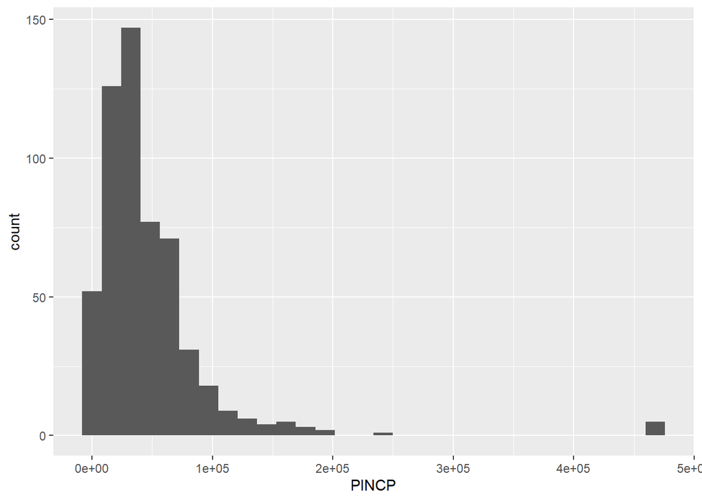

```r
hist_pincp2 <-ggplot(person_data_new, aes(x = PINCP)) +
  geom_histogram()

hist_pincp2
```

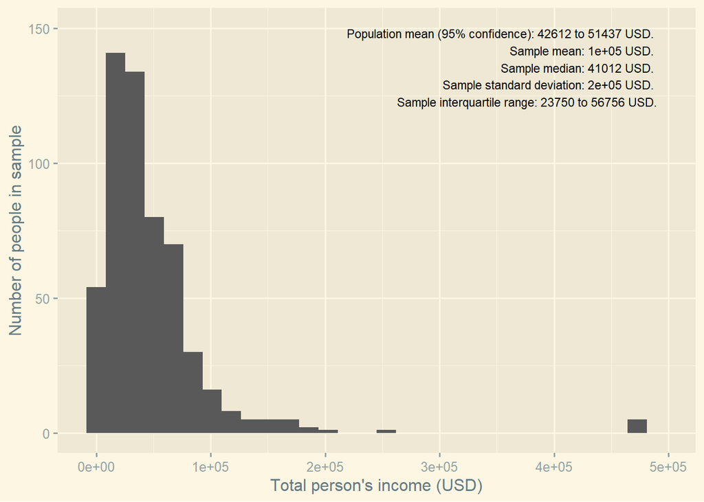

```r
hist_pincp2 +
  theme_solarized_2() +
  scale_x_continuous(name = "Total person's income (USD)") +
  scale_y_continuous(name = "Number of people in sample") +
  annotate("text", x = 490000, y = 150, size = 3,
           label = paste("Population mean (95% confidence):",
                         prettyNum(conf_int_pincp2$conf.int[1], digits = 1),
                         "to",
                         prettyNum(conf_int_pincp2$conf.int[2], digits = 1),
                         "USD.",
                         "\nSample mean:",
                         prettyNum(mean(PINCP_summary2), digits = 1), "USD.",
                         "\nSample median:",
                         prettyNum(median(PINCP_summary2), digits = 1), "USD.",
                         "\nSample standard deviation:",
                         prettyNum(sd(PINCP_summary2), digits = 1), "USD.",
                         "\nSample interquartile range:",
                         prettyNum(quantile(PINCP_summary2)["25%"], digits = 1),
                         "to",
                         prettyNum(quantile(PINCP_summary2)["75%"], digits = 1),
                         "USD."),
           hjust = 1, vjust = 1)
```

## Hours worked per week

```r
WKHP_summary2 <- summary(person_data_new$WKHP)

WKHP_summary2
```

```
##    Min. 1st Qu.  Median    Mean 3rd Qu.    Max.
##    1.00   36.00   40.00   38.56   45.00   80.00
```

```r
paste("The sample mean for hours worked per week is",
      prettyNum(mean(person_data_new$WKHP), digits = 1), "hours per week.")
```

```
## [1] "The sample mean for hours worked per week is 39 hours per week."
```

```r
paste("The sample median for hours worked per week is",
      prettyNum(median(person_data_new$WKHP), digits = 1), "hours per week.")
```

```
## [1] "The sample median for hours worked per week is 40 hours per week."
```

```r
paste("The sample standard deviation for hours worked per week is",
      prettyNum(sd(person_data_new$WKHP), digits = 1), "hours per week.")
```

```
## [1] "The sample standard deviation for hours worked per week is 12 hours per week."
```

```r
paste("The sample interquartile range for hours worked per week is",
      quantile(person_data_new$WKHP)["25%"], "to", quantile(person_data_new$WKHP)["75%"], "hours per week.")
```

```
## [1] "The sample interquartile range for hours worked per week is 36 to 45 hours per week."
```

```r
conf_int_wkhp2 <- t.test(person_data_new$WKHP)

conf_int_wkhp2
```

```
##
##  One Sample t-test
##
## data:  person_data_new$WKHP
## t = 73.259, df = 556, p-value < 2.2e-16
## alternative hypothesis: true mean is not equal to 0
## 95 percent confidence interval:
##  37.52976 39.59771
## sample estimates:
## mean of x
##  38.56373
```

```r
paste("The 95-percent confidence interval for hours worked per week  is",
      prettyNum(conf_int_wkhp2$conf.int[1], digits = 1), "to",
      prettyNum(conf_int_wkhp2$conf.int[2], digits = 1), "hours per week.")
```

```
## [1] "The 95-percent confidence interval for hours worked per week  is 38 to 40 hours per week."
```

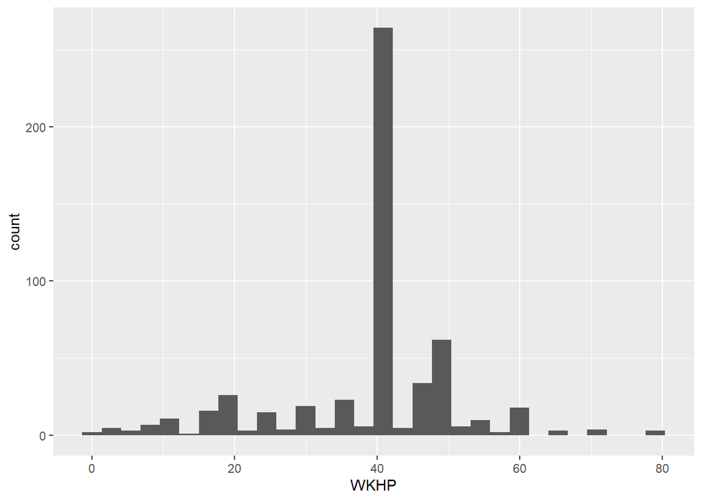

```r
hist_wkhp2 <- ggplot(person_data_new, aes(x = WKHP)) +
  geom_histogram()
hist_wkhp2
```

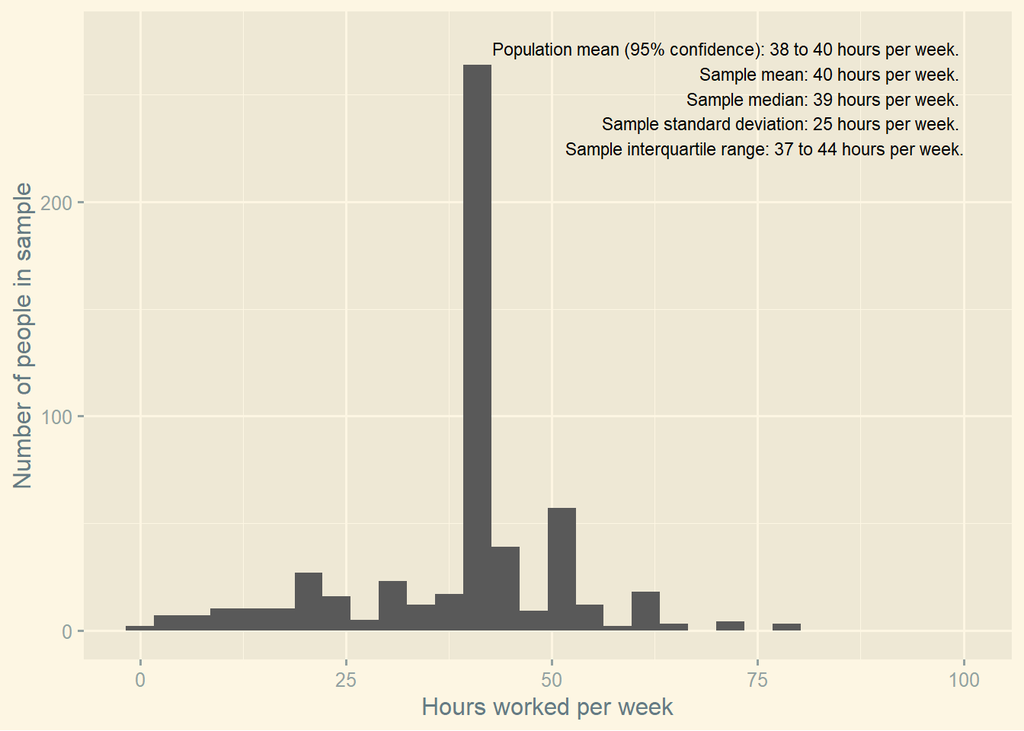

```r
hist_wkhp2 +
  theme_solarized_2() +
  scale_x_continuous(name = "Hours worked per week") +
  scale_y_continuous(name = "Number of people in sample") +
  annotate("text", x = 100, y = 275, size = 3,
           label = paste("Population mean (95% confidence):",
                         prettyNum(conf_int_wkhp2$conf.int[1], digits = 1),
                         "to",
                         prettyNum(conf_int_wkhp2$conf.int[2], digits = 1),
                         "hours per week.",
                         "\nSample mean:",
                         prettyNum(mean(WKHP_summary2), digits = 1), "hours per week.",
                         "\nSample median:",
                         prettyNum(median(WKHP_summary2), digits = 1), "hours per week.",
                         "\nSample standard deviation:",
                         prettyNum(sd(WKHP_summary2), digits = 1), "hours per week.",
                         "\nSample interquartile range:",
                         prettyNum(quantile(WKHP_summary2)["25%"], digits = 1),
                         "to",
                         prettyNum(quantile(WKHP_summary2)["75%"], digits = 1),
                         "hours per week."),
           hjust = 1, vjust = 1)
```

## Income to poverty ratio

```r
POVPIP_summary2 <- summary(person_data_new$POVPIP)

POVPIP_summary2
```

```
##    Min. 1st Qu.  Median    Mean 3rd Qu.    Max.
##     8.0   228.0   372.0   347.9   501.0   501.0
```

```r
paste("The sample mean for income to poverty ratio is",
      prettyNum(mean(person_data_new$POVPIP), digits = 1), ".")
```

```
## [1] "The sample mean for income to poverty ratio is 348 ."
```

```r
paste("The sample median for income to poverty ratio is",
      prettyNum(median(person_data_new$POVPIP), digits = 1), ".")
```

```
## [1] "The sample median for income to poverty ratio is 372 ."
```

```r
paste("The sample standard deviation for income to poverty ratio is",
      prettyNum(sd(person_data_new$POVPIP), digits = 1), ".")
```

```
## [1] "The sample standard deviation for income to poverty ratio is 145 ."
```

```r
paste("The sample interquartile range for income to poverty ratio is",
      quantile(person_data_new$POVPIP)["25%"], "to", quantile(person_data_new$POVPIP)["75%"], ".")
```

```
## [1] "The sample interquartile range for income to poverty ratio is 228 to 501 ."
```

```r
conf_int_povpip2 <- t.test(person_data_new$POVPIP)

conf_int_povpip2
```

```
##
##  One Sample t-test
##
## data:  person_data_new$POVPIP
## t = 56.578, df = 556, p-value < 2.2e-16
## alternative hypothesis: true mean is not equal to 0
## 95 percent confidence interval:
##  335.8161 359.9721
## sample estimates:
## mean of x
##  347.8941
```

```r
paste("The 95-percent confidence interval for income to poverty ratio is",
      prettyNum(conf_int_povpip2$conf.int[1], digits = 1), "to",
      prettyNum(conf_int_povpip2$conf.int[2], digits = 1), ".")
```

```
## [1] "The 95-percent confidence interval for income to poverty ratio is 336 to 360 ."
```

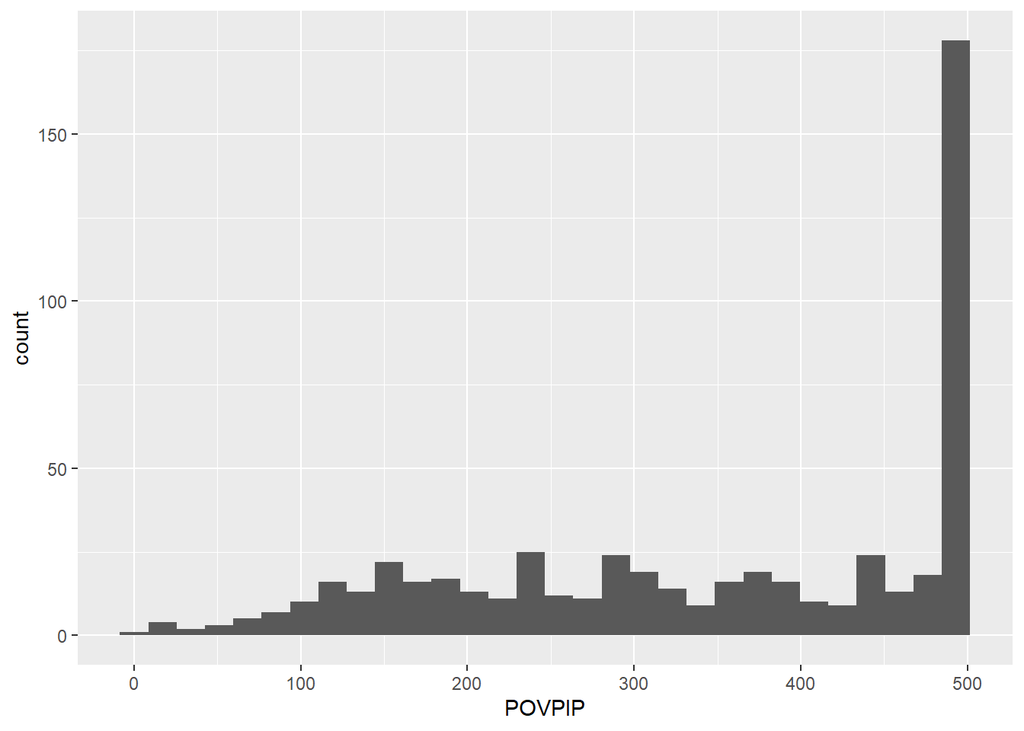

```r
hist_povpip2 <- ggplot(person_data_new, aes(x = POVPIP)) +
  geom_histogram()
hist_povpip2
```

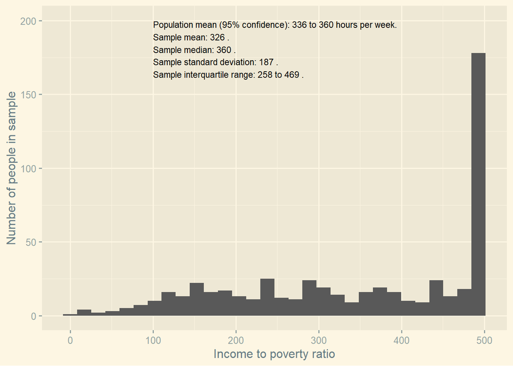

```r
hist_povpip2 +
  theme_solarized_2() +
  scale_x_continuous(name = "Income to poverty ratio") +
  scale_y_continuous(name = "Number of people in sample") +
  annotate("text", x = 100, y = 200, size = 3,
           label = paste("Population mean (95% confidence):",
                         prettyNum(conf_int_povpip2$conf.int[1], digits = 1),
                         "to",
                         prettyNum(conf_int_povpip2$conf.int[2], digits = 1),
                         "hours per week.",
                         "\nSample mean:",
                         prettyNum(mean(POVPIP_summary2), digits = 1), ".",
                         "\nSample median:",
                         prettyNum(median(POVPIP_summary2), digits = 1), ".",
                         "\nSample standard deviation:",
                         prettyNum(sd(POVPIP_summary2), digits = 1), ".",
                         "\nSample interquartile range:",
                         prettyNum(quantile(POVPIP_summary2)["25%"], digits = 1),
                         "to",
                         prettyNum(quantile(POVPIP_summary2)["75%"], digits = 1),
                         "."),
           hjust = 0, vjust = 1)
```

# Proportions of my Categorial Variables

As for my categorical variables (class of worker, household language, English language proficiency, and whether or not someone receives food stamps) below, I calculated the distribution of each by looking at the number observation in each variable category, converted the number of these observations to proportions, and calculated the 95-percent confidence interval for each of these proportions as well.

## Class of Worker (COW)

```r
unique(person_data_new$COW_label)
```

```
## [1] "Employee of a private for-profit company or business, or of an individual, for wages, salary, or commissions"
## [2] "Local government employee (city, county, etc.)"
## [3] "Employee of a private not-for-profit, tax-exempt, or charitable organization"
## [4] "Self-employed in own not incorporated business, professional practice, or farm"
## [5] "Self-employed in own incorporated business, professional practice or farm"
## [6] "State government employee"
## [7] "Federal government employee"
## [8] "Working without pay in family business or farm"
```

```r
table(person_data_new$COW_label)
```

```
##
## Employee of a private for-profit company or business, or of an individual, for wages, salary, or commissions
##                                                                                                          411
##                                 Employee of a private not-for-profit, tax-exempt, or charitable organization
##                                                                                                           32
##                                                                                  Federal government employee
##                                                                                                            8
##                                                               Local government employee (city, county, etc.)
##                                                                                                           41
##                                    Self-employed in own incorporated business, professional practice or farm
##                                                                                                           16
##                               Self-employed in own not incorporated business, professional practice, or farm
##                                                                                                           33
##                                                                                    State government employee
##                                                                                                           14
##                                                               Working without pay in family business or farm
##                                                                                                            2
```

```r
knitr::kable(table(person_data_new$COW_label), caption = "Frequency Counts for COW Variable")
```

Frequency Counts for COW Variable

| Var1 | Freq |
| --- | --- |
| Employee of a private for-profit company or business, or of an individual, for wages, salary, or commissions | 411 |
| Employee of a private not-for-profit, tax-exempt, or charitable organization | 32 |
| Federal government employee | 8 |
| Local government employee (city, county, etc.) | 41 |
| Self-employed in own incorporated business, professional practice or farm | 16 |
| Self-employed in own not incorporated business, professional practice, or farm | 33 |
| State government employee | 14 |
| Working without pay in family business or farm | 2 |

```r
table(person_data_new$COW_label) / sum(table(person_data_new$COW_label))
```

```
##
## Employee of a private for-profit company or business, or of an individual, for wages, salary, or commissions
##                                                                                                  0.737881508
##                                 Employee of a private not-for-profit, tax-exempt, or charitable organization
##                                                                                                  0.057450628
##                                                                                  Federal government employee
##                                                                                                  0.014362657
##                                                               Local government employee (city, county, etc.)
##                                                                                                  0.073608618
##                                    Self-employed in own incorporated business, professional practice or farm
##                                                                                                  0.028725314
##                               Self-employed in own not incorporated business, professional practice, or farm
##                                                                                                  0.059245961
##                                                                                    State government employee
##                                                                                                  0.025134650
##                                                               Working without pay in family business or farm
##                                                                                                  0.003590664
```

```r
mean(person_data_new$COW_label == "Employee of a private not-for-profit, tax-exempt, or charitable organization")
```

```
## [1] 0.05745063
```

```r
t.test(person_data_new$COW_label == "Employee of a private not-for-profit, tax-exempt, or charitable organization")
```

```
##
##  One Sample t-test
##
## data:  person_data_new$COW_label == "Employee of a private not-for-profit, tax-exempt, or charitable organization"
## t = 5.8215, df = 556, p-value = 9.866e-09
## alternative hypothesis: true mean is not equal to 0
## 95 percent confidence interval:
##  0.03806604 0.07683522
## sample estimates:
##  mean of x
## 0.05745063
```

```r
tenures1new <- unique(person_data_new$COW_label)
tenures1new
```

```
## [1] "Employee of a private for-profit company or business, or of an individual, for wages, salary, or commissions"
## [2] "Local government employee (city, county, etc.)"
## [3] "Employee of a private not-for-profit, tax-exempt, or charitable organization"
## [4] "Self-employed in own not incorporated business, professional practice, or farm"
## [5] "Self-employed in own incorporated business, professional practice or farm"
## [6] "State government employee"
## [7] "Federal government employee"
## [8] "Working without pay in family business or farm"
```

```r
forprofitemp <- t.test(person_data_new$COW_label == tenures1new[1])
localgovemp <- t.test(person_data_new$COW_label == tenures1new[2])
nonprofitemp <- t.test(person_data_new$COW_label == tenures1new[3])
selfemp_inc <-  t.test(person_data_new$COW_label == tenures1new[4])
selfemp_notinc <-  t.test(person_data_new$COW_label == tenures1new[5])
stategovemp <- t.test(person_data_new$COW_label == tenures1new[6])
fedgovemp <-  t.test(person_data_new$COW_label == tenures1new[7])
worknopay <-  t.test(person_data_new$COW_label == tenures1new[8])
shares <- tibble(Tenure = c("Employee of a private for-profit company or business, or of an individual, for wages, salary, or commissions",
                            "Local government employee (city, county, etc.)",
                            "Employee of a private not-for-profit, tax-exempt, or charitable organization",
                            "Self-employed in own not incorporated business, professional practice, or farm",
                            "Self-employed in own incorporated business, professional practice or farm",
                            "State government employee",
                            "Federal government employee",
                            "Working without pay in family business or farm"),
                 `Share` = c(forprofitemp$estimate,
                             localgovemp$estimate,
                             nonprofitemp$estimate,
                             selfemp_inc$estimate,
                             selfemp_notinc$estimate,
                             stategovemp$estimate,
                             fedgovemp$estimate,
                             worknopay$estimate),
                 Low = c(forprofitemp$conf.int[1],
                         localgovemp$conf.int[1],
                         nonprofitemp$conf.int[1],
                         selfemp_inc$conf.int[1],
                         selfemp_notinc$conf.int[1],
                         stategovemp$conf.int[1],
                         fedgovemp$conf.int[1],
                         worknopay$conf.int[1]),
                 High = c(forprofitemp$conf.int[2],
                         localgovemp$conf.int[2],
                         nonprofitemp$conf.int[2],
                         selfemp_inc$conf.int[2],
                         selfemp_notinc$conf.int[2],
                         stategovemp$conf.int[2],
                         fedgovemp$conf.int[2],
                         worknopay$conf.int[2]))
knitr::kable(shares, caption = "Proportions and 95-percent confidence intervals for COW variable")
```

Proportions and 95-percent confidence intervals for COW variable

| Tenure | Share | Low | High |
| --- | --- | --- | --- |
| Employee of a private for-profit company or business, or of an individual, for wages, salary, or commissions | 0.7378815 | 0.7012462 | 0.7745168 |
| Local government employee (city, county, etc.) | 0.0736086 | 0.0518556 | 0.0953616 |
| Employee of a private not-for-profit, tax-exempt, or charitable organization | 0.0574506 | 0.0380660 | 0.0768352 |
| Self-employed in own not incorporated business, professional practice, or farm | 0.0592460 | 0.0395796 | 0.0789123 |
| Self-employed in own incorporated business, professional practice or farm | 0.0287253 | 0.0148110 | 0.0426396 |
| State government employee | 0.0251346 | 0.0120950 | 0.0381743 |
| Federal government employee | 0.0143627 | 0.0044513 | 0.0242740 |
| Working without pay in family business or farm | 0.0035907 | -0.0013920 | 0.0085733 |

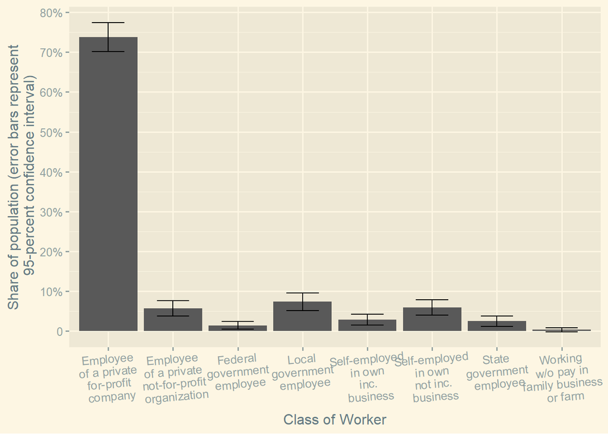

```r
ggplot(shares, aes(x = Tenure, y = Share, ymin = Low, ymax = High)) +
  geom_bar(stat = "identity") +
  geom_errorbar(width = 0.5) +
  theme_solarized_2() +
  theme(axis.text.x = element_text(angle = 5)) +
  scale_x_discrete(name = "Class of Worker",
                   labels = c("Employee \nof a private \nfor-profit \ncompany",
                  "Employee \nof a private \nnot-for-profit \norganization",
                   "Federal \ngovernment \nemployee",
                   "Local \ngovernment \nemployee",
                   "Self-employed \nin own \ninc. \nbusiness",
                   "Self-employed \nin own \nnot inc. \nbusiness",
                   "State \ngovernment \nemployee",
                  "Working \nw/o pay in \nfamily business \nor farm")) +
  scale_y_continuous(name = "Share of population (error bars represent\n 95-percent confidence interval)",
                     breaks = c(0, 0.1, 0.2, 0.3, 0.4, 0.5, 0.6, 0.7, 0.8),
                     labels = c("0", "10%", "20%", "30%", "40%", "50%", "60%", "70%", "80%"))
```

## Household Language (HHL)

```r
unique(person_data_new$HHL_label)
```

```
## [1] "Spanish"                            "English only"
## [3] "Other Indo-European languages"      "Asian and Pacific Island languages"
## [5] "Other language"                     "N/A (GQ/vacant)"
```

```r
table(person_data_new$HHL_label)
```

```
##
## Asian and Pacific Island languages                       English only
##                                 46                                283
##                    N/A (GQ/vacant)      Other Indo-European languages
##                                  1                                 25
##                     Other language                            Spanish
##                                 13                                189
```

```r
knitr::kable(table(person_data_new$HHL_label), caption = "Frequency Counts for HHL Variable")
```

Frequency Counts for HHL Variable

| Var1 | Freq |
| --- | --- |
| Asian and Pacific Island languages | 46 |
| English only | 283 |
| N/A (GQ/vacant) | 1 |
| Other Indo-European languages | 25 |
| Other language | 13 |
| Spanish | 189 |

```r
table(person_data_new$HHL_label) / sum(table(person_data_new$HHL_label))
```

```
##
## Asian and Pacific Island languages                       English only
##                        0.082585278                        0.508078995
##                    N/A (GQ/vacant)      Other Indo-European languages
##                        0.001795332                        0.044883303
##                     Other language                            Spanish
##                        0.023339318                        0.339317774
```

```r
mean(person_data_new$HHL_label == "Asian and Pacific Island languages")
```

```
## [1] 0.08258528
```

```r
t.test(person_data_new$HHL_label == "Asian and Pacific Island languages")
```

```
##
##  One Sample t-test
##
## data:  person_data_new$HHL_label == "Asian and Pacific Island languages"
## t = 7.0747, df = 556, p-value = 4.527e-12
## alternative hypothesis: true mean is not equal to 0
## 95 percent confidence interval:
##  0.05965595 0.10551460
## sample estimates:
##  mean of x
## 0.08258528
```

```r
tenures2new <- unique(person_data_new$HHL_label)
tenures2new
```

```
## [1] "Spanish"                            "English only"
## [3] "Other Indo-European languages"      "Asian and Pacific Island languages"
## [5] "Other language"                     "N/A (GQ/vacant)"
```

```r
spanish <- t.test(person_data_new$HHL_label == tenures2new[1])
english <- t.test(person_data_new$HHL_label == tenures2new[2])
other_indo_european_lang <- t.test(person_data_new$HHL_label == tenures2new[3])
asian_pi_lang <- t.test(person_data_new$HHL_label == tenures2new[4])
other_lang <- t.test(person_data_new$HHL_label == tenures2new[5])
na_vacant <- t.test(person_data_new$HHL_label == tenures2new[6])
shares <- tibble(Tenure = c("Spanish",
                            "English only",
                            "Other Indo-European languages",
                            "Asian and Pacific Island languages",
                            "Other language",
                            "N/A (GQ/vacant)"),
                 `Share` = c(spanish$estimate,
                             english$estimate,
                             other_indo_european_lang$estimate,
                             asian_pi_lang$estimate,
                             other_lang$estimate,
                             na_vacant$estimate),
                 Low = c(spanish$conf.int[1],
                         english$conf.int[1],
                         other_indo_european_lang$conf.int[1],
                         asian_pi_lang$conf.int[1],
                         other_lang$conf.int[1],
                         na_vacant$conf.int[1]),
                 High = c(spanish$conf.int[2],
                         english$conf.int[2],
                         other_indo_european_lang$conf.int[2],
                         asian_pi_lang$conf.int[2],
                         other_lang$conf.int[2],
                         na_vacant$conf.int[2]))
knitr::kable(shares, caption = "Proportions and 95-percent confidence intervals for HHL variable")
```

Proportions and 95-percent confidence intervals for HHL variable

| Tenure | Share | Low | High |
| --- | --- | --- | --- |
| Spanish | 0.3393178 | 0.2998760 | 0.3787596 |
| English only | 0.5080790 | 0.4664333 | 0.5497247 |
| Other Indo-European languages | 0.0448833 | 0.0276357 | 0.0621309 |
| Asian and Pacific Island languages | 0.0825853 | 0.0596560 | 0.1055146 |
| Other language | 0.0233393 | 0.0107624 | 0.0359162 |
| N/A (GQ/vacant) | 0.0017953 | -0.0017311 | 0.0053218 |

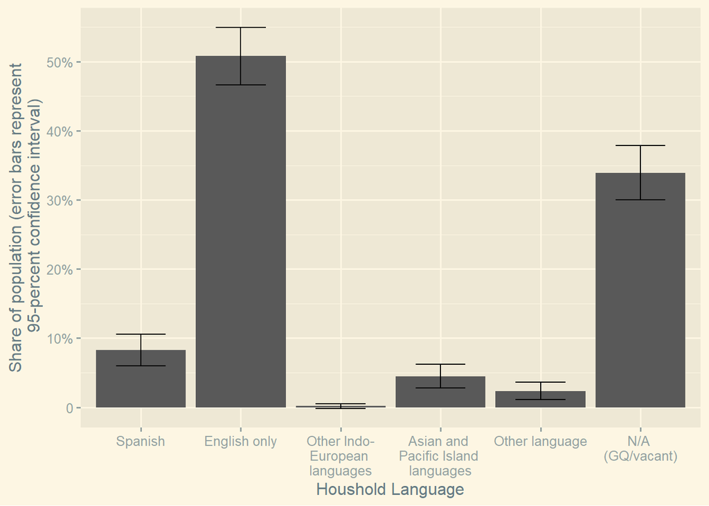

```r
ggplot(shares, aes(x = Tenure, y = Share, ymin = Low, ymax = High)) +
  geom_bar(stat = "identity") +
  geom_errorbar(width = 0.5) +
  theme_solarized_2() +
  theme(axis.text.x = element_text(angle = 0)) +
  scale_x_discrete(name = "Houshold Language",
                   labels = c("Spanish",
                            "English only",
                            "Other Indo-\nEuropean \nlanguages",
                            "Asian and \nPacific Island \nlanguages",
                            "Other language",
                            "N/A \n(GQ/vacant)")) +
  scale_y_continuous(name = "Share of population (error bars represent\n 95-percent confidence interval)",
                     breaks = c(0, 0.1, 0.2, 0.3, 0.4, 0.5),
                     labels = c("0", "10%", "20%", "30%", "40%", "50%"))
```

## Food Stamps (FS)

```r
unique(person_data_new$FS_label)
```

```
## [1] "No"  "Yes"
```

```r
table(person_data_new$FS_label)
```

```
##
##  No Yes
## 503  54
```

```r
knitr::kable(table(person_data_new$FS_label), caption = "Frequency Counts for FS Variable")
```

Frequency Counts for FS Variable

| Var1 | Freq |
| --- | --- |
| No | 503 |
| Yes | 54 |

```r
table(person_data_new$FS_label) / sum(table(person_data_new$FS_label))
```

```
##
##         No        Yes
## 0.90305206 0.09694794
```

```r
mean(person_data_new$FS_label == "No")
```

```
## [1] 0.9030521
```

```r
t.test(person_data_new$FS_label == "No")
```

```
##
##  One Sample t-test
##
## data:  person_data_new$FS_label == "No"
## t = 71.966, df = 556, p-value < 2.2e-16
## alternative hypothesis: true mean is not equal to 0
## 95 percent confidence interval:
##  0.8784040 0.9277001
## sample estimates:
## mean of x
## 0.9030521
```

```r
tenures3new <- unique(person_data_new$FS_label)
tenures3new
```

```
## [1] "No"  "Yes"
```

```r
no <- t.test(person_data_new$FS_label == tenures3new[1])
yes <- t.test(person_data_new$FS_label == tenures3new[2])
shares <- tibble(Tenure = c("No",
                            "Yes"),
                 `Share` = c(no$estimate,
                             yes$estimate),
                 Low = c(no$conf.int[1],
                         yes$conf.int[1]),
                 High = c(no$conf.int[2],
                          yes$conf.int[2]))
knitr::kable(shares, caption = "Proportions and 95-percent confidence intervals for FS variable")
```

Proportions and 95-percent confidence intervals for FS variable

| Tenure | Share | Low | High |
| --- | --- | --- | --- |
| No | 0.9030521 | 0.8784040 | 0.9277001 |
| Yes | 0.0969479 | 0.0722999 | 0.1215960 |

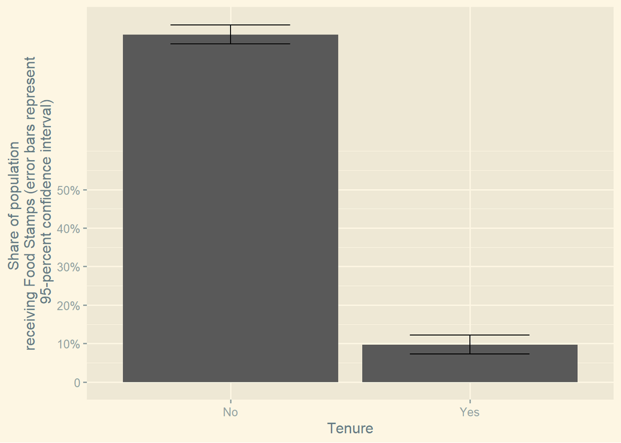

```r
ggplot(shares, aes(x = Tenure, y = Share, ymin = Low, ymax = High)) +
  geom_bar(stat = "identity") +
  geom_errorbar(width = 0.5) +
  theme_solarized_2() +
  scale_x_discrete(labels = c("No",
                            "Yes")) +
  scale_y_continuous(name = "Share of population \nreceiving Food Stamps (error bars represent\n 95-percent confidence interval)",
                     breaks = c(0, 0.1, 0.2, 0.3, 0.4, 0.5),
                     labels = c("0", "10%", "20%", "30%", "40%", "50%"))
```

## English language proficiency

```r
unique(person_data_new$ENG_label)
```

```
## [1] "Well"
## [2] "N/A (less than 5 years old/speaks only English)"
## [3] "Very well"
## [4] "Not at all"
## [5] "Not well"
```

```r
table(person_data_new$ENG_label)
```

```
##
## N/A (less than 5 years old/speaks only English)
##                                             320
##                                      Not at all
##                                              12
##                                        Not well
##                                              47
##                                       Very well
##                                             132
##                                            Well
##                                              46
```

```r
knitr::kable(table(person_data_new$ENG_label), caption = "Frequency Counts for ENG Variable")
```

Frequency Counts for ENG Variable

| Var1 | Freq |
| --- | --- |
| N/A (less than 5 years old/speaks only English) | 320 |
| Not at all | 12 |
| Not well | 47 |
| Very well | 132 |
| Well | 46 |

```r
table(person_data_new$ENG_label) / sum(table(person_data_new$ENG_label))
```

```
##
## N/A (less than 5 years old/speaks only English)
##                                      0.57450628
##                                      Not at all
##                                      0.02154399
##                                        Not well
##                                      0.08438061
##                                       Very well
##                                      0.23698384
##                                            Well
##                                      0.08258528
```

```r
mean(person_data_new$ENG_label == "Not well")
```

```
## [1] 0.08438061
```

```r
t.test(person_data_new$ENG_label == "Not well")
```

```
##
##  One Sample t-test
##
## data:  person_data_new$ENG_label == "Not well"
## t = 7.1582, df = 556, p-value = 2.599e-12
## alternative hypothesis: true mean is not equal to 0
## 95 percent confidence interval:
##  0.06122608 0.10753514
## sample estimates:
##  mean of x
## 0.08438061
```

```r
tenures4new <- unique(person_data_new$ENG_label)
tenures4new
```

```
## [1] "Well"
## [2] "N/A (less than 5 years old/speaks only English)"
## [3] "Very well"
## [4] "Not at all"
## [5] "Not well"
```

```r
well <- t.test(person_data_new$ENG_label == tenures4new[1])
lessthan5years_onlyspeakseng <- t.test(person_data_new$ENG_label == tenures4new[2])
very_well <- t.test(person_data_new$ENG_label == tenures4new[3])
not_at_all <-  t.test(person_data_new$ENG_label == tenures4new[4])
not_well <-  t.test(person_data_new$ENG_label == tenures4new[5])
shares <- tibble(Tenure = c("Well",
                            "N/A (less than 5 years old/speaks only English)",
                            "Very well",
                            "Not at all",
                            "Not well"),
                 `Share` = c(well$estimate,
                             lessthan5years_onlyspeakseng$estimate,
                             very_well$estimate,
                             not_at_all$estimate,
                             not_well$estimate),
                 Low = c(well$conf.int[1],
                         lessthan5years_onlyspeakseng$conf.int[1],
                         very_well$conf.int[1],
                         not_at_all$conf.int[1],
                         not_well$conf.int[1]),
                 High = c(well$conf.int[2],
                         lessthan5years_onlyspeakseng$conf.int[2],
                         very_well$conf.int[2],
                         not_at_all$conf.int[2],
                         not_well$conf.int[2]))
knitr::kable(shares, caption = "Proportions and 95-percent confidence intervals for ENG variable")
```

Proportions and 95-percent confidence intervals for ENG variable

| Tenure | Share | Low | High |
| --- | --- | --- | --- |
| Well | 0.0825853 | 0.0596560 | 0.1055146 |
| N/A (less than 5 years old/speaks only English) | 0.5745063 | 0.5333201 | 0.6156924 |
| Very well | 0.2369838 | 0.2015610 | 0.2724067 |
| Not at all | 0.0215440 | 0.0094494 | 0.0336386 |
| Not well | 0.0843806 | 0.0612261 | 0.1075351 |

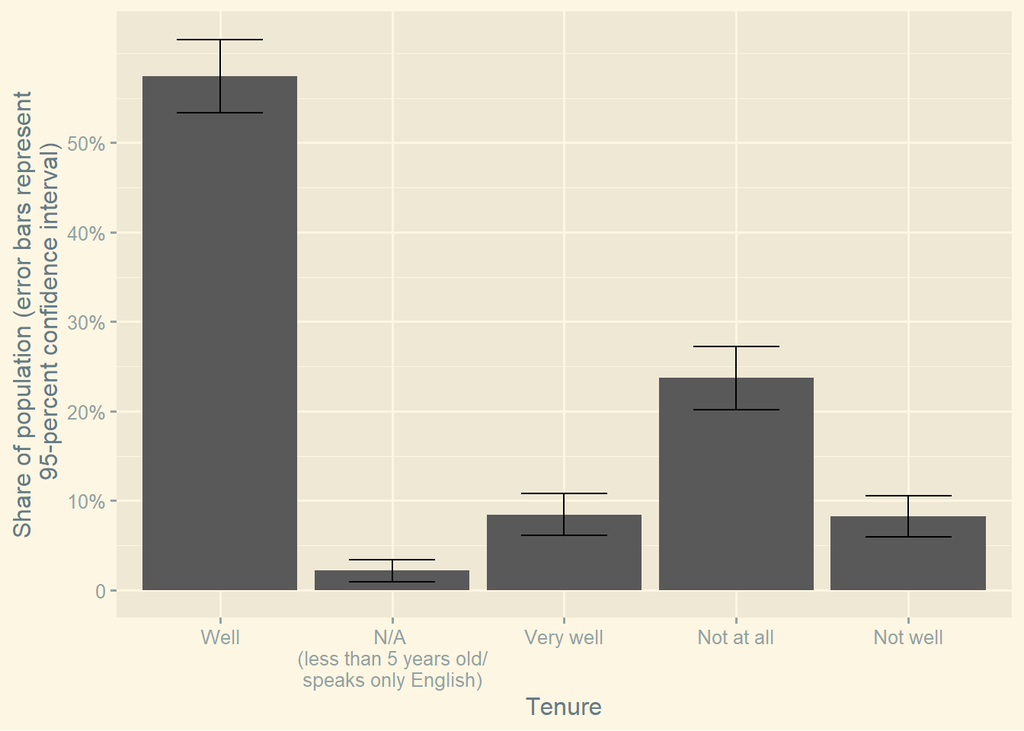

```r
ggplot(shares, aes(x = Tenure, y = Share, ymin = Low, ymax = High)) +
  geom_bar(stat = "identity") +
  geom_errorbar(width = 0.5) +
  theme_solarized_2() +
  scale_x_discrete(labels = c("Well",
                            "N/A \n(less than 5 years old/\nspeaks only English)",
                            "Very well",
                            "Not at all",
                            "Not well")) +
  scale_y_continuous(name = "Share of population (error bars represent\n 95-percent confidence interval)",
                     breaks = c(0, 0.1, 0.2, 0.3, 0.4, 0.5),
                     labels = c("0", "10%", "20%", "30%", "40%", "50%"))
```